# IODS course project

# Dimensionality reduction techniques

### The dataset

We begin by reading in the human data set:

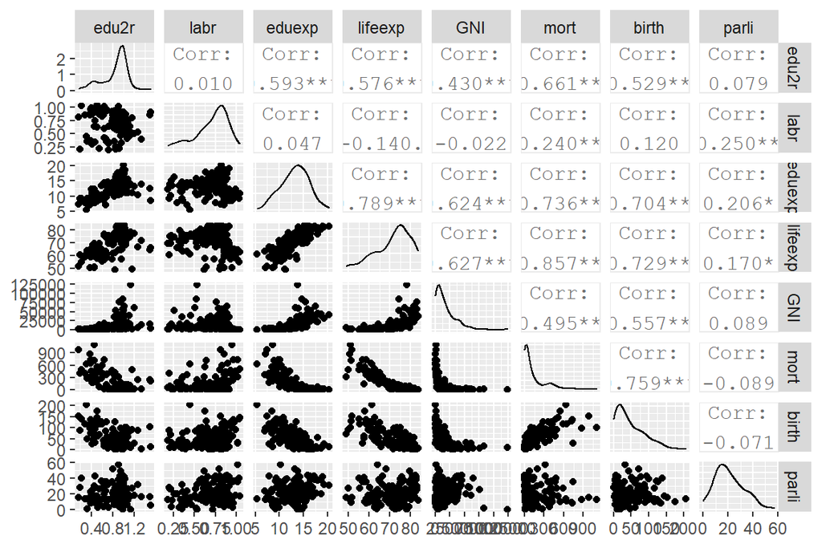

```r
library(GGally)
library(dplyr)

human <- read.csv("data/human.csv", row.names = 1)
ggpairs(human)
```

```r
summary(human)
```

```
##      edu2r             labr            eduexp         lifeexp
##  Min.   :0.1717   Min.   :0.1857   Min.   : 5.40   Min.   :49.00
##  1st Qu.:0.7264   1st Qu.:0.5984   1st Qu.:11.25   1st Qu.:66.30
##  Median :0.9375   Median :0.7535   Median :13.50   Median :74.20
##  Mean   :0.8529   Mean   :0.7074   Mean   :13.18   Mean   :71.65
##  3rd Qu.:0.9968   3rd Qu.:0.8535   3rd Qu.:15.20   3rd Qu.:77.25
##  Max.   :1.4967   Max.   :1.0380   Max.   :20.20   Max.   :83.50
##       GNI              mort            birth            parli
##  Min.   :   581   Min.   :   1.0   Min.   :  0.60   Min.   : 0.00
##  1st Qu.:  4198   1st Qu.:  11.5   1st Qu.: 12.65   1st Qu.:12.40
##  Median : 12040   Median :  49.0   Median : 33.60   Median :19.30
##  Mean   : 17628   Mean   : 149.1   Mean   : 47.16   Mean   :20.91
##  3rd Qu.: 24512   3rd Qu.: 190.0   3rd Qu.: 71.95   3rd Qu.:27.95
##  Max.   :123124   Max.   :1100.0   Max.   :204.80   Max.   :57.50
```

The distributions for all the variables appear to have a strong peak, with some variables peaking at the very low end of the range (GNI, mort, birth). There are also clear correlations between the variables. In particular, there are strong positive correlations between the following variable pairs: lifeexp and eduexp, birth and mort, GNI and lifeexp, GNI and eduexp. There are strong negative correlations between the following variable pairs: mort and lifeexp, mort and eduexp, birth and lifeexp, birth and eduexp, mort and edu2r.

### Principal component analysis

#### Non-standardized data

We first perform principal component analysis on the non-standardized human data:

```r
pca_human <- prcomp(human)
s <- summary(pca_human)
s
```

```
## Importance of components:
##                              PC1      PC2   PC3   PC4   PC5   PC6    PC7    PC8
## Standard deviation     1.854e+04 185.5219 25.19 11.45 3.766 1.566 0.1912 0.1591
## Proportion of Variance 9.999e-01   0.0001  0.00  0.00 0.000 0.000 0.0000 0.0000
## Cumulative Proportion  9.999e-01   1.0000  1.00  1.00 1.000 1.000 1.0000 1.0000
```

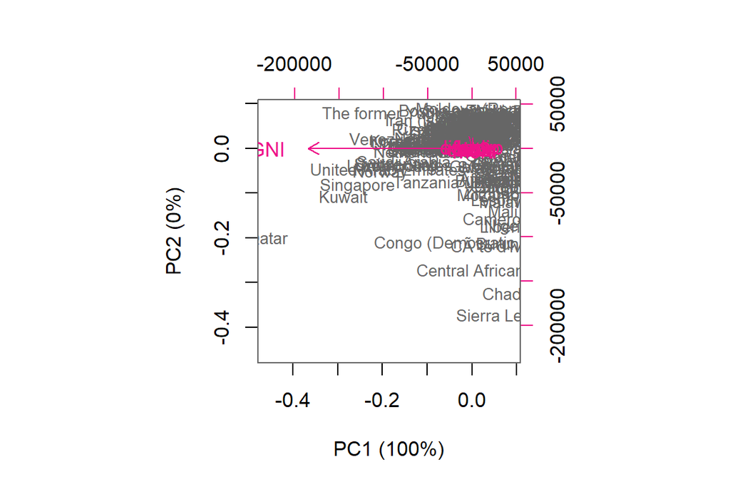

```r
pca_pr <- round(100*s$importance[2, ], digits = 1)
pc_lab <- paste0(names(pca_pr), " (", pca_pr, "%)")
biplot(pca_human, cex = c(0.8, 1), col = c("grey40", "deeppink2"), xlab = pc_lab[1], ylab = pc_lab[2])
```

Since we have not scaled (standardized) our data, the variable with the largest standard deviation dominates. The standard deviation is represented by the length of the arrow, and in this case we see that it is GNI that dominates over all the other variables. It follows that our first principle component PC1 is strongly correlated with GNI, and in fact 100% of the variation in the data is explained by the first principle component. This means that the analysis has essentially reduced the dimension of the data set to one. This is not necessarily accurate, so let us repeat the analysis by first standardizing the data:

#### Standardized data

```r
human_std <- scale(human)
pca_human <- prcomp(human_std)
s <- summary(pca_human)
s
```

```
## Importance of components:
##                           PC1    PC2     PC3     PC4     PC5     PC6     PC7
## Standard deviation     2.0708 1.1397 0.87505 0.77886 0.66196 0.53631 0.45900
## Proportion of Variance 0.5361 0.1624 0.09571 0.07583 0.05477 0.03595 0.02634
## Cumulative Proportion  0.5361 0.6984 0.79413 0.86996 0.92473 0.96069 0.98702
##                            PC8
## Standard deviation     0.32224
## Proportion of Variance 0.01298
## Cumulative Proportion  1.00000
```

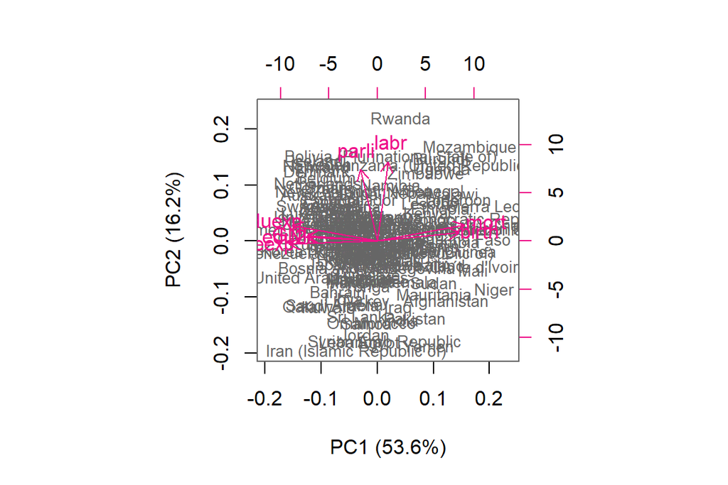

```r
pca_pr <- round(100*s$importance[2, ], digits = 1)
pc_lab <- paste0(names(pca_pr), " (", pca_pr, "%)")
biplot(pca_human, cex = c(0.8, 1), col = c("grey40", "deeppink2"), xlab = pc_lab[1], ylab = pc_lab[2])
```

We see that now the variables mort, birth, eduexp, lifeexp, GNI and edu2r are correlated with the first principal component PC1, which captures about 54% of the variability of the data. Orthogonal to this component is the second principal component PC2, correlated with the labr and parli variables and explaining about 16% of the variability. Together they explain about 70% of the variability of the data set. Here we have a two-dimensional reduction of our data set where all the original variables have a comparable contribution (standard deviation).

To recap, the difference between the two results is due to the fact that principal component analysis assumes the features with larger variance to be more important than the features with smaller variance. In the non-standardized case, GNI dominates over all the other variables as the only important one. In the (scaled) standardized case, the other variables are properly represented as well.

Our interpretation is that these country-based human development indices can be effectively reduced to two dimensions: the first principal component dimension PC1 describes health, knowledge and standard of living. The second principal component dimension PC2 describes the proportion of females in the labour force and in decision-making positions. According to the principal component analysis, these two aspects (PC1 and PC2) are orthogonal, i.e. not correlated.